# ETC5521 Tutorial 8

Going beyond two variables, exploring high dimensions

Author

Prof. Di Cook

## 🎯 Objectives

These are exercises in plots to make to explore relationships between multiple variables. You will use interactive scatterplot matrices, interactive parallel coordinate plots and tours to explore the world beyond 2D.

## 🔧 Preparation

- The reading for this week is [Cook and Laa (2023) “Interactively exploring high-dimensional data and models in R” Chapter 1](https://dicook.github.io/mulgar_book/1-intro.html).
- Complete the weekly quiz, before the deadline!
- Install the following R-packages if you do not have them already:

```r
install.packages(c("tidyverse", "tourr", "GGally", "plotly", "colorspace", "mulgar", "simputation", "naniar", "crosstalk", "sf", "ozmaps", "ggthemes"))
```

- Open your RStudio Project for this unit (the one you created in week 1, `ETC5521`). Create a `.qmd` document for this weeks activities.

## 📥 Exercises

### Exercise 1: Melbourne housing

1. Read in a copy of the Melbourne housing data from [Nick Tierney’s github repo](https://github.com/njtierney/melb-housing-data) which is a collation from the version at [kaggle](https://www.kaggle.com/anthonypino/melbourne-housing-market/version/21). It’s fairly large, so let’s start simply, and choose two suburbs to focus on. I recommend “South Yarra” and “Brighton”.

```r
mel_houses <- read_csv("https://raw.githubusercontent.com/njtierney/melb-housing-data/master/data/housing.csv") |>
  dplyr::filter(suburb %in% c("South Yarra", "Brighton"))
```

2. There are a substantial number of missing values. These need to be handled first because examining multiple variables, with almost every method, requires complete data. Examine the missing value distribution using `naniar`, and strategise on how to handle the missings.

**SolutionSolution**

This is an awful data set to wrangle into a form that can be analysed! First step is to get a sense of the missing values in each of the suburbs chosen. It is always a good idea to break it into these groups, if there aren’t too many, in case there is a difference in data handling between locations.

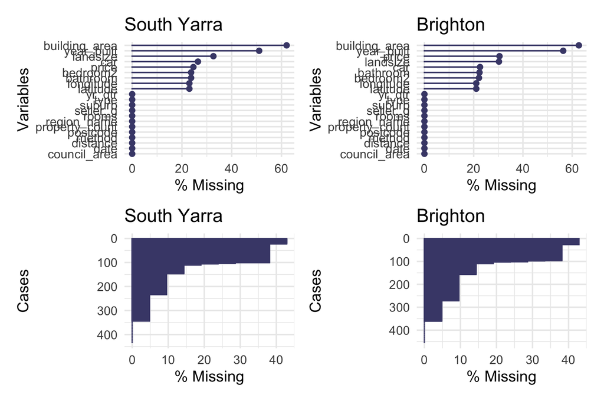

Figure 1: Plots of missing by variable and case.

```r
m1_sy <- mel_houses |> filter(suburb == "South Yarra") |> gg_miss_var(show_pct = TRUE) + ggtitle("South Yarra")
m1_b <- mel_houses |> filter(suburb == "Brighton") |> gg_miss_var(show_pct = TRUE) + ggtitle("Brighton")
m2_sy <- mel_houses |> filter(suburb == "South Yarra") |> gg_miss_case(show_pct = TRUE) + ggtitle("South Yarra")
m2_b <- mel_houses |> filter(suburb == "Brighton") |> gg_miss_case(show_pct = TRUE) + ggtitle("Brighton")
m1_sy + m1_b + m2_sy + m2_b + plot_layout(ncol=2)
```

**Summary**:

- Similar missingness in both suburbs. Although there are some slight differences, the same variables have missings and a similar number of cases have substantial missings.
- The main information about variables to note is that `building_area` and `year_built` both have more than 50% missing.

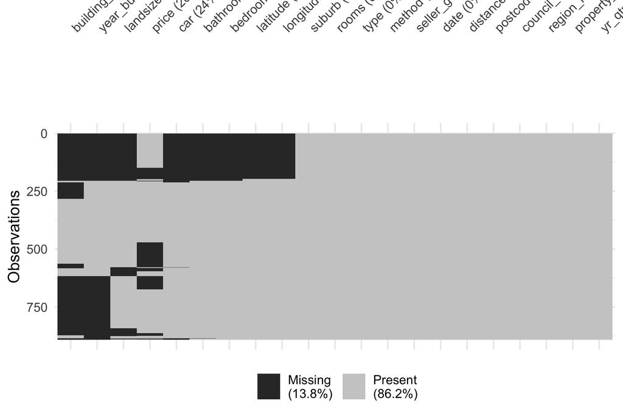

Figure 2: Overall summary of missing values, with variables and cases grouped.

```r
m3 <- vis_miss(mel_houses, cluster = TRUE, sort_miss = TRUE)
m3
```

**Summary**:

There are co-occurring missings.

- If `bedroom2` is missing then likely `bathroom`, `landsize`, `car`, `latitude` and `longitude` are missing.
- When `price` is missing, most other variables are available - this is good!
- But often `price` and `landsize` are both missing.
- There is a small amount of sporadic missing values other than these.

**Strategy**:

- remove/ignore the two worst variables, `building_area` and `year_built` which have more missings than present data.
- remove observations that have missings on all of these variables: `landsize`, `car`, `bathroom`, `bedroom2`, `bathroom`, `latitude`, `longitude`. There is not enough information in the remaining variables to be able to impute the missing values.

To impute missing values the choice is to fit a regression model on complete records. (We have previously noted in lecture that to impute price we need to take into account other variables because missingness appears to depend on other variables.) This will be done in pieces, to impute price when observations on all other variables are available, we will use these.

3. Now implement your strategy for removing, and imputing missing values, until you have a complete data set. This can involve some iteration on the strategy, as we find that some other approach is needed.

**SolutionSolution**

We will separate date into year and quarter, as these might be useful for the imputation - prices will change from year to year, and, from experience, we know that there are some seasonal differences in property prices.